# KL Divergence

The Kullback-Leibler Divergence (KL Divergence), is a measure from information theory that quantifies how one probability distribution (Q) differs from a true or reference probability distribution (P).

Think of it as "how much extra information is needed to describe the data if you use distribution Q to approximate distribution P." A higher KL divergence means that Q is a poorer approximation of P, leading to more "surprise" or "information loss."

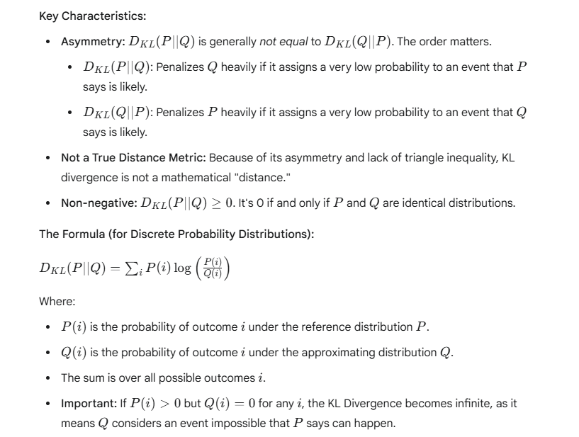

Example: Comparing Customer Preferences for Movie Genres

Imagine a streaming service is analyzing customer preferences for three movie genres: Action, Comedy, and Drama.

Scenario: We have a "true" or ideal distribution of preferences we'd like to see from our users (e.g., from a market research survey, or a target demographic). Let's call this Ideal Distribution (P).

P (Ideal Customer Preferences):

- Action: 40% (0.4)
- Comedy: 30% (0.3)
- Drama: 30% (0.3)

Now, we observe the actual preferences of a new segment of users (Segment X). Let's call this Observed Distribution (Q).

Q (Segment X Preferences):

- Action: 50% (0.5)
- Comedy: 40% (0.4)
- Drama: 10% (0.1)

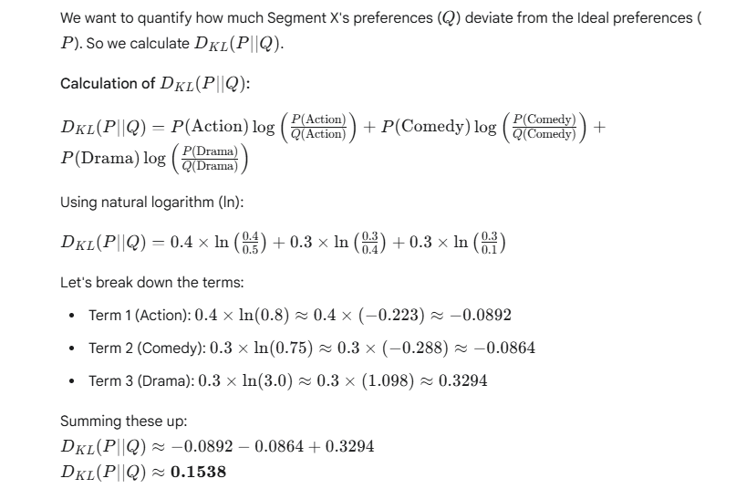

Interpretation:

The KL Divergence of approximately 0.1538 tells us that there's a measurable difference between the Ideal customer preferences (P) and the Observed preferences of Segment X (Q).

What contributed most to the divergence? The largest positive contribution came from the "Drama" genre (0.3294). This is because the Ideal distribution (P) expected 30% for Drama, but Segment X (Q) only showed 10%. This means Q significantly underestimates the probability of Drama relative to P, leading to a larger "surprise" or "information loss" if you use Q to describe P. The negative contributions from Action and Comedy mean that Q overestimates these probabilities compared to P, which reduces the overall divergence. In this scenario, a streaming service might use this information to:

Target Segment X with more Drama content if they want to nudge them towards the "ideal" preference. Understand that Segment X is less interested in Drama than the general ideal, and tailor recommendations accordingly. KL Divergence provides a single, quantitative measure of how much one probability distribution diverges from another, making it a powerful tool in various data analysis and machine learning tasks.

# Notebook Structure

1. Import necessary libraries
2. Define the utility function - KL Divergence
3. Calculate KL Divergence between different distribution